# Mapas ENSANUT 2018

Diego López Tamayo [^1]

# Directorio y librería

```r
# Configuración
rm(list = ls())
# Paqueterías
pacman::p_load(tidyverse,
               ggplot2,
               viridis,
               sf,
               sp,
               #gmodels,
               tmap,
               leaflet,
               #foreign,
               #expss,
               #fishualize,
               #raster,
               #cowplot
               #ggspatial,
               #colorspace
            )
```

```
##
## Your package installed
```

# Shapes

Cargamos las Bases de datos geoespaciales (del INEGI) en R. Para más detalles de cómo funcionan los datos geoespaciales reomiendo el tutorial de [Emmanuel Maruri](https://e-maruri.github.io/Mapas.html)

```r
# Mapas a nivel Estado
mapa_mex_edos <- st_read("mg_sep2019_integrado/conjunto_de_datos/00ent.shp",
                         options = "ENCODING=WINDOWS-1252")
```

```
## options:        ENCODING=WINDOWS-1252
```

```r
glimpse(mapa_mex_edos)
```

```
## Rows: 32
## Columns: 4
## $ CVEGEO   <chr> "01", "02", "03", "04", "05", "06", "07", "08", "09", "10", …
## $ CVE_ENT  <chr> "01", "02", "03", "04", "05", "06", "07", "08", "09", "10", …
## $ NOMGEO   <chr> "Aguascalientes", "Baja California", "Baja California Sur", …
## $ geometry <MULTIPOLYGON [m]> MULTIPOLYGON (((2470518 115..., MULTIPOLYGON ((…
```

```r
# Mapas a nivel Municipal
mapa_mex_mun <- st_read("mg_sep2019_integrado/conjunto_de_datos/00mun.shp",
                        options = "ENCODING=WINDOWS-1252")
```

```
## options:        ENCODING=WINDOWS-1252
```

```r
glimpse(mapa_mex_mun)
```

```
## Rows: 2,465
## Columns: 5
## $ CVEGEO   <chr> "01001", "01002", "01003", "01004", "01005", "01006", "01007…
## $ CVE_ENT  <chr> "01", "01", "01", "01", "01", "01", "01", "01", "01", "01", …
## $ CVE_MUN  <chr> "001", "002", "003", "004", "005", "006", "007", "008", "009…
## $ NOMGEO   <chr> "Aguascalientes", "Asientos", "Calvillo", "Cosío", "Jesús Ma…
## $ geometry <MULTIPOLYGON [m]> MULTIPOLYGON (((2489073 111..., MULTIPOLYGON ((…
```

# ENSANUT 2018

La Secretaría de Salud, el [Instituto Nacional de Salud Pública (INSP)](https://www.insp.mx/) y el [Instituto Nacional de Estadística y Geografía (INEGI)](https://www.inegi.org.mx/), llevan a cabo el levantamiento de la [Encuesta Nacional de Salud y Nutrición (ENSANUT) 2018](https://ensanut.insp.mx/), con el objeto de conocer el estado de salud y las condiciones nutricionales de la población en México.

A continuación, utilizamos los microdatos disponibles [aquí](https://ensanut.insp.mx/encuestas/ensanut2018/descargas.php) para mapear la prevalencia de las principales enfermedades (diabetes, hipertensión y obesidad) en el país a nivel municipal.

En aspectos metodológicos la ENSANUT sigue la metodología de Unidad de Observación Vivienda, Hogares y el diseño estadístico de INEGI, por lo que podemos asociar los resultados presentados con los datos geoespaciales a nivel municipal. A continuación se muestra el proceso.

## Datos de ensanut a nivel municipal

Importamos los microdatos del **Componente de SALUD** $\Rightarrow$ **Información sobre la vivienda** a R desde el [repositorio de Github](https://github.com/diego-eco/shiny_app_ensut) donde están organizados.

```r
ensanut_ap <- read.csv(
  file ="https://raw.githubusercontent.com/diego-eco/shiny_app_ensut/master/data/ensanut_areas_peq.csv",
                       sep=",",
                       colClasses=c(rep('character', 6), 'numeric','numeric','numeric')
                        )
names(ensanut_ap) <- c("CVEGEO", "ent", "ent_nom", "mun_clave", "mun_nom",
                       "estimador", "Obesidad", "Hipertension", "Diabetes")
# Un vistazo rápido de la base
glimpse(ensanut_ap)
```

```
## Rows: 2,457
## Columns: 9
## $ CVEGEO       <chr> "01001", "01002", "01003", "01004", "01005", "01006", "0…
## $ ent          <chr> "1", "1", "1", "1", "1", "1", "1", "1", "1", "1", "1", "…
## $ ent_nom      <chr> "Aguascalientes", "Aguascalientes", "Aguascalientes", "A…
## $ mun_clave    <chr> "1", "2", "3", "4", "5", "6", "7", "8", "9", "10", "11",…
## $ mun_nom      <chr> "Aguascalientes", "Asientos", "Calvillo", "Cosío", "Jesú…
## $ estimador    <chr> "Valor", "Valor", "Valor", "Valor", "Valor", "Valor", "V…
## $ Obesidad     <dbl> 31.5, 32.3, 40.0, 32.6, 34.7, 24.1, 31.7, 31.3, 32.0, 35…
## $ Hipertension <dbl> 14.9, 15.3, 13.8, 16.4, 12.4, 12.8, 14.3, 14.9, 14.7, 16…
## $ Diabetes     <dbl> 7.5, 8.0, 9.2, 7.4, 6.7, 7.4, 6.9, 6.2, 7.2, 7.6, 7.2, 9…
```

Notas que es importante que la columna de “mun” (municipios) del componente de salud de la ENSANUT la renombremos a “CVEGEO” para que coincida con la columna de los datos geoespaciales a nivel municipal.

Teniendo lo anterior listo, podemos unir las bases de datos para “añadir” los datos de ENSANUT a nuestra base de datos geoespaciales.

```r
#Unir ambas bases
datos <- dplyr::left_join(mapa_mex_mun, ensanut_ap, by = c("CVEGEO"))
# Un vistazo rápido de la base
glimpse(datos)
```

```
## Rows: 2,465
## Columns: 13
## $ CVEGEO       <chr> "01001", "01002", "01003", "01004", "01005", "01006", "0…
## $ CVE_ENT      <chr> "01", "01", "01", "01", "01", "01", "01", "01", "01", "0…
## $ CVE_MUN      <chr> "001", "002", "003", "004", "005", "006", "007", "008", …
## $ NOMGEO       <chr> "Aguascalientes", "Asientos", "Calvillo", "Cosío", "Jesú…
## $ ent          <chr> "1", "1", "1", "1", "1", "1", "1", "1", "1", "1", "1", "…
## $ ent_nom      <chr> "Aguascalientes", "Aguascalientes", "Aguascalientes", "A…
## $ mun_clave    <chr> "1", "2", "3", "4", "5", "6", "7", "8", "9", "10", "11",…
## $ mun_nom      <chr> "Aguascalientes", "Asientos", "Calvillo", "Cosío", "Jesú…
## $ estimador    <chr> "Valor", "Valor", "Valor", "Valor", "Valor", "Valor", "V…
## $ Obesidad     <dbl> 31.5, 32.3, 40.0, 32.6, 34.7, 24.1, 31.7, 31.3, 32.0, 35…
## $ Hipertension <dbl> 14.9, 15.3, 13.8, 16.4, 12.4, 12.8, 14.3, 14.9, 14.7, 16…
## $ Diabetes     <dbl> 7.5, 8.0, 9.2, 7.4, 6.7, 7.4, 6.9, 6.2, 7.2, 7.6, 7.2, 9…
## $ geometry     <MULTIPOLYGON [m]> MULTIPOLYGON (((2489073 111..., MULTIPOLYGO…
```

Podemos ver que en nuestra base “datos” tenemos listo los datos de diabetes, hipertensión y obesidad asociados a su variable “geometry” que nos permite mapear a nivel municipal.

# Cuantiles

Antes de mapear, debemos tener en cuenta que tenemos el dato del **porcentaje de población de 20 años y más con diagnóstico previp de la enfermedad** para cada uno de los 2,465 municipios en México. No podemos mapear directamente estos datos porque necesitaríamos al menos 2,000 colores distintos en el mapa (asumiendo que algunos municipios tiene el mimso porcentaje que otros). Esto no es práctico en términos de cómputo ni en visualización de datos. Para más detalles sobre el propóstito de mapear ver [¿Por qué usar mapas?](https://diego-eco.github.io/files/Mapas_en_R.html#%C2%BFPor_qu%C3%A9_usar_mapas).

Por lo anterior, es importante antes de mapear dividir nuestras observaciones en **cuantiles o rangos** para poder asignar un color a cada uno. Esto se puede entender como “juntar” varias observaciones que compartan porcentajes cercanos, y asignarlas a un grupo/color.

Hay varias formas de agrupar los datos, a continuación mostramos un ejemplos con la variable de Diabetes:

Para extraer los cuantiles usamos las funciones: - [pull()](https://dplyr.tidyverse.org/reference/pull.html) Parecido a select(), [pero no igual](https://stackoverflow.com/questions/49844902/difference-between-pull-and-select-in-dplyr) - [quantile()](https://statisticsglobe.com/quantile-function-in-r-example)

Para crear las etiquetas utilizamos: - [imap_chr()](https://purrr.tidyverse.org/reference/index.html) También vea [aquí](http://zevross.com/blog/2019/06/11/the-power-of-three-purrr-poseful-iteration-in-r-with-map-pmap-and-imap/)

```r
# ¿Cuántas clases quiero?
no_classes <- 5
# Extraer cuantiles
cuantil_diab <- datos %>%
  pull(Diabetes) %>%
  quantile(probs = seq(0, 1, length.out = no_classes + 1),na.rm=T) %>%
  as.vector() # to remove names of quantiles, so idx below is numeric
# Así se crean las etiquetas
labels_diab <- imap_chr(cuantil_diab, function(., idx){
  return(paste0(round(cuantil_diab[idx] , 0),
                "%",
                " – ",
                round(cuantil_diab[idx + 1] , 0),
                "%"))
})
# Podemos observar los cuantiles que genera
cuantil_diab
```

```
## [1]  2.1  8.5  9.5 10.7 12.0 31.7
```

```r
# Se elimina la última etiqueta del vector labels
# En caso contrario tendríamos una categoría que iría hasta NA
labels_diab <- labels_diab[1:length(labels_diab) - 1]
labels_diab
```

```
## [1] "2% – 8%"   "8% – 10%"  "10% – 11%" "11% – 12%" "12% – 32%"
```

Creamos la variable para cuantiles de Diabetes en la base de datos con la función [cut()](https://www.rdocumentation.org/packages/base/versions/3.6.2/topics/cut) [ver tamibén](https://www.r-bloggers.com/r-function-of-the-day-cut-2/)

```r
# Crear la variable en datos
datos <- datos %>%
  mutate(q_Diabetes = cut(Diabetes,
                         breaks = cuantil_diab,
                         labels = labels_diab,
                         include.lowest = T))
glimpse(datos)
```

```
## Rows: 2,465
## Columns: 14
## $ CVEGEO       <chr> "01001", "01002", "01003", "01004", "01005", "01006", "0…
## $ CVE_ENT      <chr> "01", "01", "01", "01", "01", "01", "01", "01", "01", "0…
## $ CVE_MUN      <chr> "001", "002", "003", "004", "005", "006", "007", "008", …
## $ NOMGEO       <chr> "Aguascalientes", "Asientos", "Calvillo", "Cosío", "Jesú…
## $ ent          <chr> "1", "1", "1", "1", "1", "1", "1", "1", "1", "1", "1", "…
## $ ent_nom      <chr> "Aguascalientes", "Aguascalientes", "Aguascalientes", "A…
## $ mun_clave    <chr> "1", "2", "3", "4", "5", "6", "7", "8", "9", "10", "11",…
## $ mun_nom      <chr> "Aguascalientes", "Asientos", "Calvillo", "Cosío", "Jesú…
## $ estimador    <chr> "Valor", "Valor", "Valor", "Valor", "Valor", "Valor", "V…
## $ Obesidad     <dbl> 31.5, 32.3, 40.0, 32.6, 34.7, 24.1, 31.7, 31.3, 32.0, 35…
## $ Hipertension <dbl> 14.9, 15.3, 13.8, 16.4, 12.4, 12.8, 14.3, 14.9, 14.7, 16…
## $ Diabetes     <dbl> 7.5, 8.0, 9.2, 7.4, 6.7, 7.4, 6.9, 6.2, 7.2, 7.6, 7.2, 9…
## $ geometry     <MULTIPOLYGON [m]> MULTIPOLYGON (((2489073 111..., MULTIPOLYGO…
## $ q_Diabetes   <fct> 2% – 8%, 2% – 8%, 8% – 10%, 2% – 8%, 2% – 8%, 2% – 8%, 2…
```

Ahora tenemos una nueva columna en neustra base de datos llamada q_Diabetes con la categoría asociada al municipio. Y nuestros 2,465 municipios ahora pueden agruparse en 5 clases y mapear de mejor forma, como ejemplo:

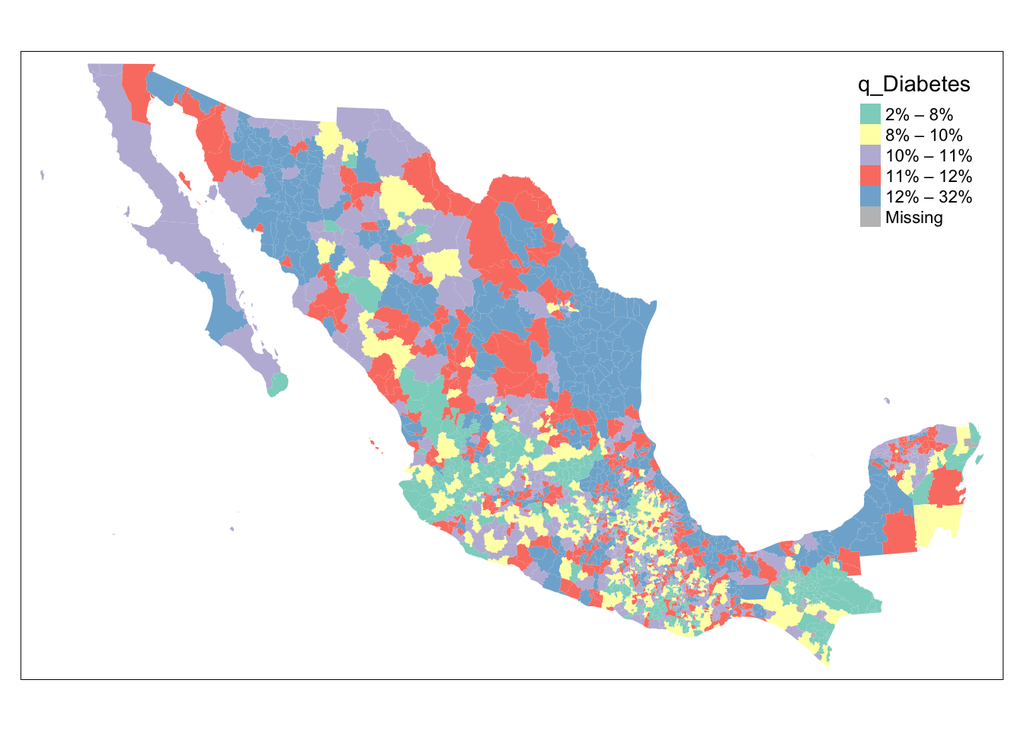

```r
# Mapa prevalencia de diabetes con 5 clases a nivel municipal
tm_shape(datos) +
  tm_fill(col = "q_Diabetes")
```

En la siguiente sección presentamos los mapas con mayor detalle y estilo. Pero antes vamos a crear los cuantiles para nuestras otras dos variables: Hipertensión y Obesidad siguiendo el mismo procedimiento.

```r
# ¿Cuántas clases quiero?
no_classes <- 5
# Extraer cuantiles
cuantil_hiper <- datos %>%
  pull(Hipertension) %>%
  quantile(probs = seq(0, 1, length.out = no_classes + 1),na.rm=T) %>%
  as.vector() # to remove names of quantiles, so idx below is numeric
# Así se crean las etiquetas
labels_hiper <- imap_chr(cuantil_hiper, function(., idx){
  return(paste0(round(cuantil_hiper[idx] , 0),
                "%",
                " – ",
                round(cuantil_hiper[idx + 1] , 0),
                "%"))
})

# Se elimina la última etiqueta
# En caso contrario sería hasta NA
labels_hiper <- labels_hiper[1:length(labels_hiper) - 1]

# Crear la variable en la base de datos
datos <- datos %>%
  mutate(q_Hipertension = cut(Hipertension,
                          breaks = cuantil_hiper,
                          labels = labels_hiper,
                          include.lowest = T))
```

```r
# ¿Cuántas clases quiero?
no_classes <- 5
# Extraer cuantiles
cuantil_obes <- datos %>%
  pull(Obesidad) %>%
  quantile(probs = seq(0, 1, length.out = no_classes + 1),na.rm=T) %>%
  as.vector() # to remove names of quantiles, so idx below is numeric
# Así se crean las etiquetas
labels_obes <- imap_chr(cuantil_obes, function(., idx){
  return(paste0(round(cuantil_obes[idx] , 0),
                "%",
                " – ",
                round(cuantil_obes[idx + 1] , 0),
                "%"))
})

# Se elimina la última etiqueta
# En caso contrario sería hasta NA
labels_obes <- labels_obes[1:length(labels_obes) - 1]

# Crear la variable
datos <- datos %>%
  mutate(q_Obesidad = cut(Obesidad,
                              breaks = cuantil_obes,
                              labels = labels_obes,
                              include.lowest = T))
```

```r
glimpse(datos)
```

```
## Rows: 2,465
## Columns: 16
## $ CVEGEO         <chr> "01001", "01002", "01003", "01004", "01005", "01006", …
## $ CVE_ENT        <chr> "01", "01", "01", "01", "01", "01", "01", "01", "01", …
## $ CVE_MUN        <chr> "001", "002", "003", "004", "005", "006", "007", "008"…
## $ NOMGEO         <chr> "Aguascalientes", "Asientos", "Calvillo", "Cosío", "Je…
## $ ent            <chr> "1", "1", "1", "1", "1", "1", "1", "1", "1", "1", "1",…
## $ ent_nom        <chr> "Aguascalientes", "Aguascalientes", "Aguascalientes", …
## $ mun_clave      <chr> "1", "2", "3", "4", "5", "6", "7", "8", "9", "10", "11…
## $ mun_nom        <chr> "Aguascalientes", "Asientos", "Calvillo", "Cosío", "Je…
## $ estimador      <chr> "Valor", "Valor", "Valor", "Valor", "Valor", "Valor", …
## $ Obesidad       <dbl> 31.5, 32.3, 40.0, 32.6, 34.7, 24.1, 31.7, 31.3, 32.0, …
## $ Hipertension   <dbl> 14.9, 15.3, 13.8, 16.4, 12.4, 12.8, 14.3, 14.9, 14.7, …
## $ Diabetes       <dbl> 7.5, 8.0, 9.2, 7.4, 6.7, 7.4, 6.9, 6.2, 7.2, 7.6, 7.2,…
## $ geometry       <MULTIPOLYGON [m]> MULTIPOLYGON (((2489073 111..., MULTIPOLY…
## $ q_Diabetes     <fct> 2% – 8%, 2% – 8%, 8% – 10%, 2% – 8%, 2% – 8%, 2% – 8%,…
## $ q_Hipertension <fct> 3% – 15%, 3% – 15%, 3% – 15%, 15% – 18%, 3% – 15%, 3% …
## $ q_Obesidad     <fct> 30% – 34%, 30% – 34%, 40% – 80%, 30% – 34%, 34% – 40%,…
```

Ahora tenemos listas nuestras 3 columnas en la base de datos llamadas q_Diabetes, q_Hipertension y q_Obesidad con la categoría asociada al municipio.

Notar que para las 3 enfermedades dividimos en 5 cateogrías al inicio de cada chunk, podemos repetir el proceso agreganod y quitando categorías o hacerlo interactivo en una [Shiny app](https://diego-lopezt.shinyapps.io/shiny_app_ensut).